# Test Utility

Klinkenberg

9 jan 2020

# Test Utility

## What is Test Utility

Test Utility literally refers to using a test as a utility, as a tool. And in our context we mean using tests as a toal for selection.

### Costs and benefits

- monetary
- non-monetary

The psychometric properties of the test determine the relationship between costs and benefits.

These properties can be empirically tested. We will show you the reasoning process in this lecture.

## Predictive / Criterion Validity

Often we want to predict based on test scores how an individual will perform at a later time.

- The thing we want to predict is called the **criterion**
  - Example: good employees or good students
- The test we use to predict is obviously called the **predictor**

The predictive validity is defined as the correlation between the **predictor** / test score and the **criterion**.

**NOTE:** This is no different than the $R$ in regular regression analysis; the correlation between the outcome and the model.

With a correlation of zero,  
selection is useless

## Cut-off scores

Based on our criterion and predictor we need to determine:

> 1. When we trully know someone is competent.
> 2. At what predictor score we want to select someone.

That means setting a:

> - Cut-off for the criterion (Base Rate)
> - Cut-off for the predictor (Selection Ratio)

## Utility (interactive)

### Counts and margins

| FN | TP | 0 |
| --- | --- | --- |
| TN | FP | 0 |
| 0 | 0 | 0 |

**What is the:**

- Correlation = 0.796
- Hit Rate
- Base Rate
- Sensitivity
- Specificity

## CASE STUDY:

Admission test (NL: selectie aan de poort)

- Test week data from UvA Psychology students
  - Motivation
  - Study results
- The data was gathered before we actually had admission tests (all students where admitted).
- Because of this, we can determine the effectiveness of a supposed admissions procedure.
- We can calculate how much better our results would be if we had actually selected.
- This comparison will show us how much there is to gain and the price we have to pay

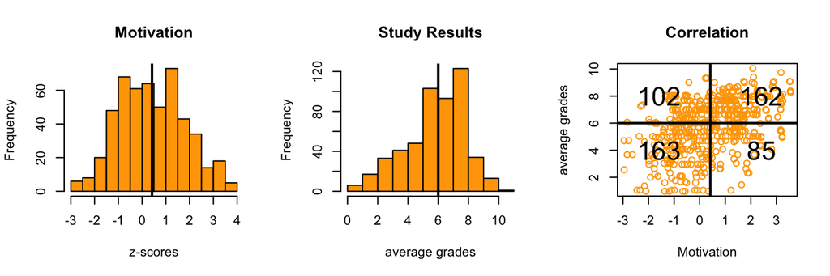

- Average Motivation: 0.417
- Pass mark: 6
- Correlation: 0.407

## Hit Rate

| FN 102 | TP 162 |
| --- | --- |
| TN 163 | FP 85 |

Percentage of correct conclusions.

$$\definecolor{green}{RGB}{0,128,0}
\text{Hit Rate} = \frac{{\color{green}\text{TP}} + \color{green}\text{TN}}{N}$$

$$\frac{162 + 163}{512} = 0.63$$

## Base Rate

| FN 102 | TP 162 |
| --- | --- |
| TN 163 | FP 85 |

Percentage of correct conclusions when not selecting.

$$\definecolor{red}{RGB}{255,0,0}
\text{Base Rate} = \frac{{\color{green}\text{TP}} + \color{red}\text{FN}}{N}$$

$$\frac{162 + 102}{512} = 0.52$$

## Hit Rate - Base Rate

To determine the benefit of selection, we need to know what the hit rate is compared to the base rate.

$$\text{Hit Rate} - \text{Base Rate} = \text{Benefit}$$

$$0.63 - 0.52 = 0.11$$

## Sensitivity

| FN 102 | TP 162 |
| --- | --- |
| TN 163 | FP 85 |

We can determine the efficiency of selection by calculating the sensitivity and specificity of a test.

**Sensitivity:** Percentage of eligible candidates that will be selected.

$$\text{Sensitivity} = \frac{\color{green}\text{TP}}{{\color{red}\text{FN}} + \color{green}\text{TP}}$$

$$\frac{162}{102 + 162} = 0.61$$

The lower the sensitivity  
The more frustrated  
parents and students

## Specificity

| FN 102 | TP 162 |
| --- | --- |
| TN 163 | FP 85 |

**Specificity:** Percentage of inapt candidates that will be rejected.

$$\text{Specificity} = \frac{\color{green}\text{TN}}{{\color{green}\text{TN}} + \color{red}\text{FP}}$$

$$\frac{163}{163 + 85} = 0.66$$

## Steps to determine efficiency

1. Select predictor and criterion
2. Calculate the correlation in an unselected sample
3. Determine the efficiency based on possible cut-off scores

Only if you select everyone  
you can determine  
the quality of the procedure

## Taylor-Russell Tables

So, what if you do not have the resources to conduct empirical research?

In that case, you can resort to using Taylor-Russell tables, hhich provide estimates of the percentage of eligible candidates of those selected.

- TABLE: Base Rate
- Y-AXIS: Predictive validity
- X-AXIS: Selection ratio
- CELLS: Proportion satisfactory among those selected = $\frac{\color{green}\text{TP}}{{\color{green}\text{TP}} + \color{red}\text{FP}}$

[Taylor, H, and Russell, J. “The Relationship of Validity Coefficients to the Practical Effectiveness of Tests in Selection: Discussion and Tables.” Journal of Applied Psychology 23 (1939): n. pag. Web.](https://lib.uva.nl/permalink/31UKB_UAM1_INST/h37vvk/proquest1290354749)

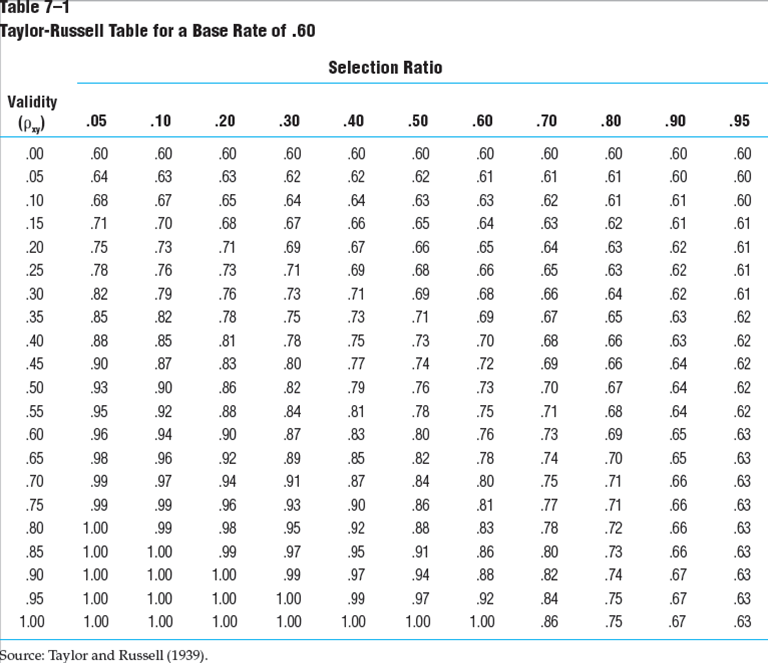

## Influential factors

The two factors influencing the cell values “The proportion satisfactory among those selected” are:

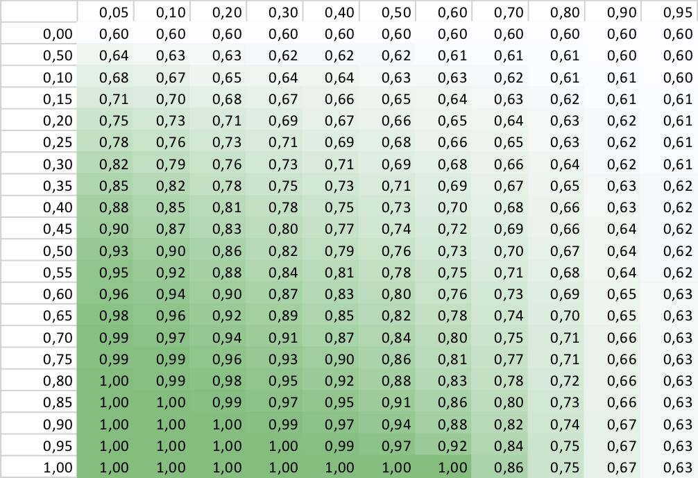

- Predictive validity
- Selection ratio

## Increase efficiency

So, there are two ways to increase efficiency

- Increase predictive validity
- Use more extreme selection ratio

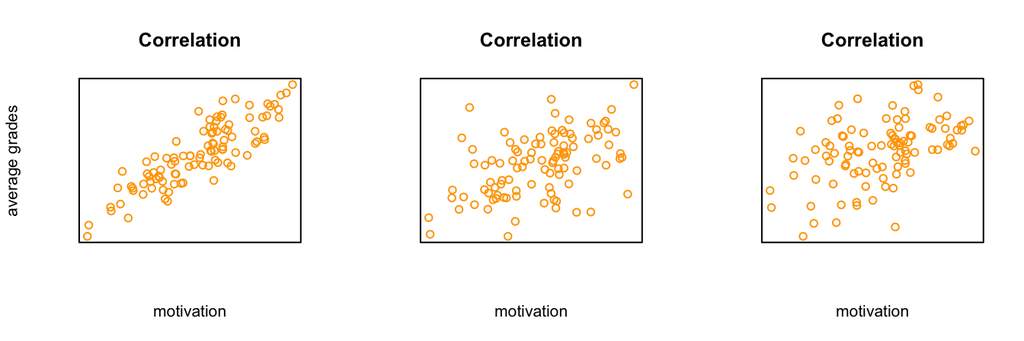

## Threats to validity

Criterion validity is threatened by all factors that reduce the relation between predictor and criterion.

- Unreliable tests: noise reduces the relation.
- Other validity issues
- Wrong predictor
- Restriction of range: restrictions in test scores results in lower correlation.

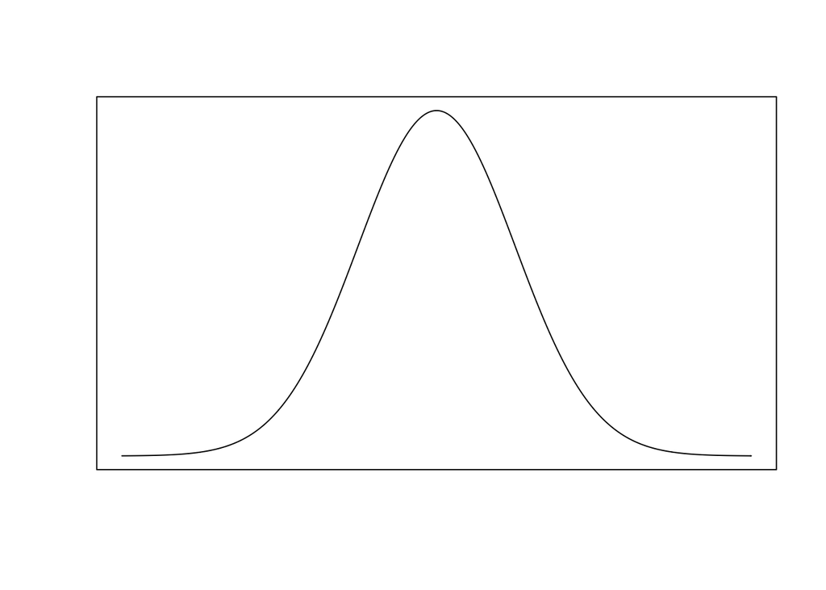

## Increase validity

Criterion validity can be increased by all measures that increase the correlation.

- Higher reliability: more items, deleting bad items
- Use better predictor
- Less restriction of range

Just wanting selection  
to work does not  
influence the quality  
of selection

## Problems with selection in NL

- Correlation between predictors and success is low
- We have a bad selection ratio

## Why selection works in US

- High correlation
  - More variation vs NL
  - NL has restriction of range (VWO/HAVO/VMBO) vs high school in US
- Prestigious Ivy League universities have good selection ratio
  - They select very few students; Harvard selects 10% highest SAT

## Wrap-up

- Good selection needs high criterion validity
- The higher the correlation the higher the gain
- The efficiency can be determined in advance.
  - When selection is implemented, you can not determine the efficiency
- If criterion validity suffers from restriction of range, then the efficiency argument does not hold.
  - Policy should not be based on psychometric argumentation.

# End

- [@shklinkenberg](https://twitter.com/shklinkenberg)
- [Klinkenberg](https://www.linkedin.com/in/sharonklinkenberg/)
- ln.AvU@grebneknilK.S
- ShKlinkenberg